# COVID Analysis: Philippines vs Japan

K. Chu

9/25/2021

I’m from the Philippines, and I got curious how the situation looks like. However, I have moved to Japan for work, and I’m also curious what the situation looks like here. Am I safer here in Japan, or should I go back home to the Philippines?

```r
library(tidyverse)
library(lubridate)
url_in <- "https://raw.githubusercontent.com/CSSEGISandData/COVID-19/master/csse_covid_19_data/csse_covid_19_time_series/"

filenames <- c("time_series_covid19_confirmed_global.csv",
               "time_series_covid19_deaths_global.csv",
               "time_series_covid19_recovered_global.csv")
urls <- str_c(url_in, filenames)
global_cases <- read_csv(urls[1])
global_deaths <- read_csv(urls[2])
global_recoveries <- read_csv(urls[3])
summary(global_cases)
```

```
##  Province/State     Country/Region          Lat              Long
##  Length:279         Length:279         Min.   :-51.80   Min.   :-178.12
##  Class :character   Class :character   1st Qu.:  4.86   1st Qu.: -23.04
##  Mode  :character   Mode  :character   Median : 21.52   Median :  20.94
##                                        Mean   : 20.31   Mean   :  22.50
##                                        3rd Qu.: 40.46   3rd Qu.:  85.24
##                                        Max.   : 71.71   Max.   : 178.06
##                                        NA's   :2        NA's   :2
##     1/22/20           1/23/20           1/24/20           1/25/20
##  Min.   :  0.000   Min.   :  0.000   Min.   :  0.000   Min.   :  0.00
##  1st Qu.:  0.000   1st Qu.:  0.000   1st Qu.:  0.000   1st Qu.:  0.00
##  Median :  0.000   Median :  0.000   Median :  0.000   Median :  0.00
##  Mean   :  1.996   Mean   :  2.348   Mean   :  3.373   Mean   :  5.14
##  3rd Qu.:  0.000   3rd Qu.:  0.000   3rd Qu.:  0.000   3rd Qu.:  0.00
##  Max.   :444.000   Max.   :444.000   Max.   :549.000   Max.   :761.00
##
##     1/26/20            1/27/20           1/28/20           1/29/20
##  Min.   :   0.000   Min.   :   0.00   Min.   :   0.00   Min.   :   0.0
##  1st Qu.:   0.000   1st Qu.:   0.00   1st Qu.:   0.00   1st Qu.:   0.0
##  Median :   0.000   Median :   0.00   Median :   0.00   Median :   0.0
##  Mean   :   7.591   Mean   :  10.49   Mean   :  19.99   Mean   :  22.1
##  3rd Qu.:   0.000   3rd Qu.:   0.00   3rd Qu.:   0.00   3rd Qu.:   0.0
##  Max.   :1058.000   Max.   :1423.00   Max.   :3554.00   Max.   :3554.0
##
##     1/30/20           1/31/20            2/1/20            2/2/20
##  Min.   :   0.00   Min.   :   0.00   Min.   :   0.00   Min.   :    0.00
##  1st Qu.:   0.00   1st Qu.:   0.00   1st Qu.:   0.00   1st Qu.:    0.00
##  Median :   0.00   Median :   0.00   Median :   0.00   Median :    0.00
##  Mean   :  29.52   Mean   :  35.58   Mean   :  43.15   Mean   :   60.17
##  3rd Qu.:   0.00   3rd Qu.:   0.00   3rd Qu.:   0.00   3rd Qu.:    0.00
##  Max.   :4903.00   Max.   :5806.00   Max.   :7153.00   Max.   :11177.00
##
##      2/3/20             2/4/20             2/5/20             2/6/20
##  Min.   :    0.00   Min.   :    0.00   Min.   :    0.00   Min.   :    0.0
##  1st Qu.:    0.00   1st Qu.:    0.00   1st Qu.:    0.00   1st Qu.:    0.0
##  Median :    0.00   Median :    0.00   Median :    0.00   Median :    0.0
##  Mean   :   71.28   Mean   :   85.66   Mean   :   99.08   Mean   :  110.4
##  3rd Qu.:    0.00   3rd Qu.:    0.00   3rd Qu.:    0.00   3rd Qu.:    0.0
##  Max.   :13522.00   Max.   :16678.00   Max.   :19665.00   Max.   :22112.0
##
```

[output cut: 1185 more lines]

```
##  Min.   :       0   Min.   :       0   Min.   :       0   Min.   :       0
##  1st Qu.:    2382   1st Qu.:    2576   1st Qu.:    2577   1st Qu.:    2579
##  Median :   35817   Median :   36428   Median :   36746   Median :   36746
##  Mean   :  813822   Mean   :  815947   Mean   :  817858   Mean   :  819143
##  3rd Qu.:  354706   3rd Qu.:  355712   3rd Qu.:  356334   3rd Qu.:  356402
##  Max.   :41785903   Max.   :41993789   Max.   :42050638   Max.   :42088171
##
##     9/20/21            9/21/21            9/22/21            9/23/21
##  Min.   :       0   Min.   :       0   Min.   :       0   Min.   :       0
##  1st Qu.:    2582   1st Qu.:    2586   1st Qu.:    2587   1st Qu.:    2592
##  Median :   36994   Median :   37018   Median :   37036   Median :   37048
##  Mean   :  821080   Mean   :  822760   Mean   :  824687   Mean   :  826529
##  3rd Qu.:  358015   3rd Qu.:  358430   3rd Qu.:  359994   3rd Qu.:  359994
##  Max.   :42289819   Max.   :42410607   Max.   :42543510   Max.   :42672241
##
```

```r
summary(global_deaths)
```

```
##  Province/State     Country/Region          Lat              Long
##  Length:279         Length:279         Min.   :-51.80   Min.   :-178.12
##  Class :character   Class :character   1st Qu.:  4.86   1st Qu.: -23.04
##  Mode  :character   Mode  :character   Median : 21.52   Median :  20.94
##                                        Mean   : 20.31   Mean   :  22.50
##                                        3rd Qu.: 40.46   3rd Qu.:  85.24
##                                        Max.   : 71.71   Max.   : 178.06
##                                        NA's   :2        NA's   :2
##     1/22/20            1/23/20            1/24/20            1/25/20
##  Min.   : 0.00000   Min.   : 0.00000   Min.   : 0.00000   Min.   : 0.0000
##  1st Qu.: 0.00000   1st Qu.: 0.00000   1st Qu.: 0.00000   1st Qu.: 0.0000
##  Median : 0.00000   Median : 0.00000   Median : 0.00000   Median : 0.0000
##  Mean   : 0.06093   Mean   : 0.06452   Mean   : 0.09319   Mean   : 0.1505
##  3rd Qu.: 0.00000   3rd Qu.: 0.00000   3rd Qu.: 0.00000   3rd Qu.: 0.0000
##  Max.   :17.00000   Max.   :17.00000   Max.   :24.00000   Max.   :40.0000
##
##     1/26/20           1/27/20           1/28/20            1/29/20
##  Min.   : 0.0000   Min.   : 0.0000   Min.   :  0.0000   Min.   :  0.0000
##  1st Qu.: 0.0000   1st Qu.: 0.0000   1st Qu.:  0.0000   1st Qu.:  0.0000
##  Median : 0.0000   Median : 0.0000   Median :  0.0000   Median :  0.0000
##  Mean   : 0.2007   Mean   : 0.2939   Mean   :  0.4695   Mean   :  0.4767
##  3rd Qu.: 0.0000   3rd Qu.: 0.0000   3rd Qu.:  0.0000   3rd Qu.:  0.0000
##  Max.   :52.0000   Max.   :76.0000   Max.   :125.0000   Max.   :125.0000
##
##     1/30/20            1/31/20             2/1/20             2/2/20
##  Min.   :  0.0000   Min.   :  0.0000   Min.   :  0.0000   Min.   :  0.000
##  1st Qu.:  0.0000   1st Qu.:  0.0000   1st Qu.:  0.0000   1st Qu.:  0.000
##  Median :  0.0000   Median :  0.0000   Median :  0.0000   Median :  0.000
##  Mean   :  0.6129   Mean   :  0.7634   Mean   :  0.9283   Mean   :  1.298
##  3rd Qu.:  0.0000   3rd Qu.:  0.0000   3rd Qu.:  0.0000   3rd Qu.:  0.000
##  Max.   :162.0000   Max.   :204.0000   Max.   :249.0000   Max.   :350.000
##
##      2/3/20            2/4/20            2/5/20            2/6/20
##  Min.   :  0.000   Min.   :  0.000   Min.   :  0.000   Min.   :  0.000
##  1st Qu.:  0.000   1st Qu.:  0.000   1st Qu.:  0.000   1st Qu.:  0.000
##  Median :  0.000   Median :  0.000   Median :  0.000   Median :  0.000
##  Mean   :  1.527   Mean   :  1.763   Mean   :  2.022   Mean   :  2.272
##  3rd Qu.:  0.000   3rd Qu.:  0.000   3rd Qu.:  0.000   3rd Qu.:  0.000
##  Max.   :414.000   Max.   :479.000   Max.   :549.000   Max.   :618.000
##
```

[output cut: 1177 more lines]

```
##  Min.   :     0   Min.   :     0.0   Min.   :     0.0   Min.   :     0.0
##  1st Qu.:    13   1st Qu.:    13.5   1st Qu.:    13.5   1st Qu.:    13.5
##  Median :   553   Median :   561.0   Median :   566.0   Median :   566.0
##  Mean   : 16771   Mean   : 16795.1   Mean   : 16816.7   Mean   : 16845.9
##  3rd Qu.:  5810   3rd Qu.:  5815.0   3rd Qu.:  5821.5   3rd Qu.:  5878.5
##  Max.   :672635   Max.   :673472.0   Max.   :673774.0   Max.   :676076.0
##
##     9/21/21            9/22/21            9/23/21
##  Min.   :     0.0   Min.   :     0.0   Min.   :     0.0
##  1st Qu.:    14.5   1st Qu.:    14.5   1st Qu.:    14.5
##  Median :   566.0   Median :   579.0   Median :   583.0
##  Mean   : 16878.5   Mean   : 16914.6   Mean   : 16949.3
##  3rd Qu.:  5887.0   3rd Qu.:  5894.0   3rd Qu.:  5898.5
##  Max.   :678407.0   Max.   :681192.0   Max.   :684349.0
##
```

```r
summary(global_recoveries)
```

```
##  Province/State     Country/Region          Lat               Long
##  Length:264         Length:264         Min.   :-51.796   Min.   :-178.117
##  Class :character   Class :character   1st Qu.:  4.553   1st Qu.:  -9.563
##  Mode  :character   Mode  :character   Median : 19.313   Median :  24.603
##                                        Mean   : 18.883   Mean   :  27.857
##                                        3rd Qu.: 38.912   3rd Qu.:  93.195
##                                        Max.   : 71.707   Max.   : 178.065
##                                        NA's   :1         NA's   :1
##     1/22/20           1/23/20           1/24/20           1/25/20
##  Min.   : 0.0000   Min.   : 0.0000   Min.   : 0.0000   Min.   : 0.0000
##  1st Qu.: 0.0000   1st Qu.: 0.0000   1st Qu.: 0.0000   1st Qu.: 0.0000
##  Median : 0.0000   Median : 0.0000   Median : 0.0000   Median : 0.0000
##  Mean   : 0.1136   Mean   : 0.1212   Mean   : 0.1477   Mean   : 0.1591
##  3rd Qu.: 0.0000   3rd Qu.: 0.0000   3rd Qu.: 0.0000   3rd Qu.: 0.0000
##  Max.   :28.0000   Max.   :28.0000   Max.   :31.0000   Max.   :32.0000
##
##     1/26/20           1/27/20           1/28/20           1/29/20
##  Min.   : 0.0000   Min.   : 0.0000   Min.   : 0.0000   Min.   : 0.0000
##  1st Qu.: 0.0000   1st Qu.: 0.0000   1st Qu.: 0.0000   1st Qu.: 0.0000
##  Median : 0.0000   Median : 0.0000   Median : 0.0000   Median : 0.0000
##  Mean   : 0.2121   Mean   : 0.2462   Mean   : 0.4091   Mean   : 0.4811
##  3rd Qu.: 0.0000   3rd Qu.: 0.0000   3rd Qu.: 0.0000   3rd Qu.: 0.0000
##  Max.   :42.0000   Max.   :45.0000   Max.   :80.0000   Max.   :88.0000
##
##     1/30/20           1/31/20             2/1/20            2/2/20
##  Min.   : 0.0000   Min.   :  0.0000   Min.   :  0.000   Min.   :  0.000
##  1st Qu.: 0.0000   1st Qu.:  0.0000   1st Qu.:  0.000   1st Qu.:  0.000
##  Median : 0.0000   Median :  0.0000   Median :  0.000   Median :  0.000
##  Mean   : 0.5492   Mean   :  0.8523   Mean   :  1.087   Mean   :  1.803
##  3rd Qu.: 0.0000   3rd Qu.:  0.0000   3rd Qu.:  0.000   3rd Qu.:  0.000
##  Max.   :90.0000   Max.   :141.0000   Max.   :168.000   Max.   :295.000
##
##      2/3/20            2/4/20            2/5/20           2/6/20
##  Min.   :  0.000   Min.   :  0.000   Min.   :  0.00   Min.   :  0.000
##  1st Qu.:  0.000   1st Qu.:  0.000   1st Qu.:  0.00   1st Qu.:  0.000
##  Median :  0.000   Median :  0.000   Median :  0.00   Median :  0.000
##  Mean   :  2.375   Mean   :  3.246   Mean   :  4.28   Mean   :  5.655
##  3rd Qu.:  0.000   3rd Qu.:  0.000   3rd Qu.:  0.00   3rd Qu.:  0.000
##  Max.   :386.000   Max.   :522.000   Max.   :633.00   Max.   :817.000
##
```

[output cut: 1169 more lines]

```
##  Min.   :0   Min.   :0   Min.   :0   Min.   :0   Min.   :0   Min.   :0
##  1st Qu.:0   1st Qu.:0   1st Qu.:0   1st Qu.:0   1st Qu.:0   1st Qu.:0
##  Median :0   Median :0   Median :0   Median :0   Median :0   Median :0
##  Mean   :0   Mean   :0   Mean   :0   Mean   :0   Mean   :0   Mean   :0
##  3rd Qu.:0   3rd Qu.:0   3rd Qu.:0   3rd Qu.:0   3rd Qu.:0   3rd Qu.:0
##  Max.   :0   Max.   :0   Max.   :0   Max.   :0   Max.   :0   Max.   :0
##
##     9/21/21     9/22/21     9/23/21
##  Min.   :0   Min.   :0   Min.   :0
##  1st Qu.:0   1st Qu.:0   1st Qu.:0
##  Median :0   Median :0   Median :0
##  Mean   :0   Mean   :0   Mean   :0
##  3rd Qu.:0   3rd Qu.:0   3rd Qu.:0
##  Max.   :0   Max.   :0   Max.   :0
##
```

```r
# rename the columns with slashes
global_cases <- global_cases %>%
  rename(Country_Region=`Country/Region`,
         Province_State=`Province/State`)

global_deaths <- global_deaths %>%
  rename(Country_Region=`Country/Region`,
         Province_State=`Province/State`)

global_recoveries <- global_recoveries %>%
  rename(Country_Region=`Country/Region`,
         Province_State=`Province/State`)
```

I am getting my data from the Center for Systems Science and Engineering (CSSE) at Johns Hopkins University. They have a GitHub repository for global cases, deaths, and recoveries, so I will be using this repository.

The three files here contain a lot of information, but they show a tally of cases or deaths or recoveries per country per day, with each day being a new column. We have a very wide table. Since I want to more easily see the number of cases, deaths, and recoveries, I will have to transform the data.

However, for recoveries, it appears that we don’t have recorded data past August 4, 2021, as we get 0s from August 5, 2021 onward. I will also have to address this in my transformation.

```r
recoveries_last_available_date <- "2021-08-04"
```

```r
# get philippine cases
ph_cases <- global_cases %>%
  filter(Country_Region == "Philippines") %>%
  pivot_longer(cols= -c(Province_State,
                        Country_Region,
                        Lat,
                        Long),
               names_to="date",
               values_to="cases") %>%
  select(-c(Lat, Long))

summary(ph_cases)
```

```
##  Province_State     Country_Region         date               cases
##  Length:611         Length:611         Length:611         Min.   :      0
##  Class :character   Class :character   Class :character   1st Qu.:  31254
##  Mode  :character   Mode  :character   Mode  :character   Median : 418818
##                                                           Mean   : 587700
##                                                           3rd Qu.: 984560
##                                                           Max.   :2434753
```

```r
# get philippine deaths
ph_deaths <- global_deaths %>%
  filter(Country_Region == "Philippines") %>%
  pivot_longer(cols= -c(Province_State,
                        Country_Region,
                        Lat,
                        Long),
               names_to="date",
               values_to="deaths") %>%
  select(-c(Lat, Long))

summary(ph_deaths)
```

```
##  Province_State     Country_Region         date               deaths
##  Length:611         Length:611         Length:611         Min.   :    0
##  Class :character   Class :character   Class :character   1st Qu.: 1182
##  Mode  :character   Mode  :character   Mode  :character   Median : 8123
##                                                           Mean   :10473
##                                                           3rd Qu.:16602
##                                                           Max.   :37405
```

```r
# get philippine recoveries
ph_recoveries <- global_recoveries %>%
  filter(Country_Region == "Philippines") %>%
  pivot_longer(cols= -c(Province_State,
                        Country_Region,
                        Lat,
                        Long),
               names_to="date",
               values_to="recoveries") %>%
  select(-c(Lat, Long))

summary(ph_recoveries)
```

```
##  Province_State     Country_Region         date             recoveries
##  Length:611         Length:611         Length:611         Min.   :      0
##  Class :character   Class :character   Class :character   1st Qu.:   1264
##  Mode  :character   Mode  :character   Mode  :character   Median : 255046
##                                                           Mean   : 380957
##                                                           3rd Qu.: 535122
##                                                           Max.   :1528422
```

```r
# combine them into ph_data
ph_data <- ph_cases %>%
  full_join(ph_deaths) %>%
  full_join(ph_recoveries) %>%
  mutate(date = mdy(date)) %>%
  filter(cases > 0)
# mark the recoveries as NA past the last available date for recoveries
ph_data$recoveries <- ifelse(ph_data$date > as.Date(recoveries_last_available_date),
                             NA,
                             ph_data$recoveries)

summary(ph_data)
```

```
##  Province_State     Country_Region          date                cases
##  Length:603         Length:603         Min.   :2020-01-30   Min.   :      1
##  Class :character   Class :character   1st Qu.:2020-06-28   1st Qu.:  35947
##  Mode  :character   Mode  :character   Median :2020-11-26   Median : 424297
##                                        Mean   :2020-11-26   Mean   : 595497
##                                        3rd Qu.:2021-04-25   3rd Qu.:1001976
##                                        Max.   :2021-09-23   Max.   :2434753
##
##      deaths        recoveries
##  Min.   :    0   Min.   :      0
##  1st Qu.: 1250   1st Qu.:   6552
##  Median : 8242   Median : 348760
##  Mean   :10612   Mean   : 420913
##  3rd Qu.:16818   3rd Qu.: 561902
##  Max.   :37405   Max.   :1528422
##                  NA's   :50
```

Here, I filtered out the data for the Philippines. I also transformed the tables using pivot_longer so that I can more easily visualize the data. I joined the two tables together so that I can pair the number of cases with the number of deaths. I’m also more interested in seeing things after the Philippines started having cases, so I only retained the rows that had at least one case.

As of this writing, the latest entry was for September 23, 2021, with the number of total cases over time being 2,434,753 and the number of total deaths being 37,405. The number of recoveries, as of August 4, 2021, is 1,528,422.

```r
# get japan cases
jp_cases <- global_cases %>%
  filter(Country_Region == "Japan") %>%
  pivot_longer(cols= -c(Province_State,
                        Country_Region,
                        Lat,
                        Long),
               names_to="date",
               values_to="cases") %>%
  select(-c(Lat, Long))

summary(jp_cases)
```

```
##  Province_State     Country_Region         date               cases
##  Length:611         Length:611         Length:611         Min.   :      2
##  Class :character   Class :character   Class :character   1st Qu.:  17850
##  Mode  :character   Mode  :character   Mode  :character   Median : 133034
##                                                           Mean   : 351284
##                                                           3rd Qu.: 561187
##                                                           Max.   :1688929
```

```r
# get japan deaths
jp_deaths <- global_deaths %>%
  filter(Country_Region == "Japan") %>%
  pivot_longer(cols= -c(Province_State,
                        Country_Region,
                        Lat,
                        Long),
               names_to="date",
               values_to="deaths") %>%
  select(-c(Lat, Long))

summary(jp_deaths)
```

```
##  Province_State     Country_Region         date               deaths
##  Length:611         Length:611         Length:611         Min.   :    0
##  Class :character   Class :character   Class :character   1st Qu.:  960
##  Mode  :character   Mode  :character   Mode  :character   Median : 1943
##                                                           Mean   : 5505
##                                                           3rd Qu.: 9862
##                                                           Max.   :17397
```

```r
# get japan recoveries
jp_recoveries <- global_recoveries %>%
  filter(Country_Region == "Japan") %>%
  pivot_longer(cols= -c(Province_State,
                        Country_Region,
                        Lat,
                        Long),
               names_to="date",
               values_to="recoveries") %>%
  select(-c(Lat, Long))

summary(jp_recoveries)
```

```
##  Province_State     Country_Region         date             recoveries
##  Length:611         Length:611         Length:611         Min.   :     0
##  Class :character   Class :character   Class :character   1st Qu.:  4068
##  Mode  :character   Mode  :character   Mode  :character   Median : 76700
##                                                           Mean   :212247
##                                                           3rd Qu.:414523
##                                                           Max.   :852451
```

```r
# combine them all into jp_data
jp_data <- jp_cases %>%
  full_join(jp_deaths) %>%
  full_join(jp_recoveries) %>%
  mutate(date = mdy(date)) %>%
  filter(cases > 0)
# mark the recoveries as NA past the last available date for recoveries
jp_data$recoveries <- ifelse(jp_data$date > as.Date(recoveries_last_available_date),
                             NA,
                             jp_data$recoveries)

summary(jp_data)
```

```
##  Province_State     Country_Region          date                cases
##  Length:611         Length:611         Min.   :2020-01-22   Min.   :      2
##  Class :character   Class :character   1st Qu.:2020-06-22   1st Qu.:  17850
##  Mode  :character   Mode  :character   Median :2020-11-22   Median : 133034
##                                        Mean   :2020-11-22   Mean   : 351284
##                                        3rd Qu.:2021-04-23   3rd Qu.: 561187
##                                        Max.   :2021-09-23   Max.   :1688929
##
##      deaths        recoveries
##  Min.   :    0   Min.   :     0
##  1st Qu.:  960   1st Qu.: 15217
##  Median : 1943   Median : 89765
##  Mean   : 5505   Mean   :231164
##  3rd Qu.: 9862   3rd Qu.:428627
##  Max.   :17397   Max.   :852451
##                  NA's   :50
```

I did the same transformation for the Japanese data. The numbers look better here, compared to the Philippines. The number of total cases over time is 1,688,929 as of September 23, 2021, and the number of total deaths over time is 17,397.

The number of recoveries, as of August 4, 2021, is 852,451. This might appear low, but given that the number of cases is relatively low compared to the Philippines, I think that this wouldn’t be unexpected.

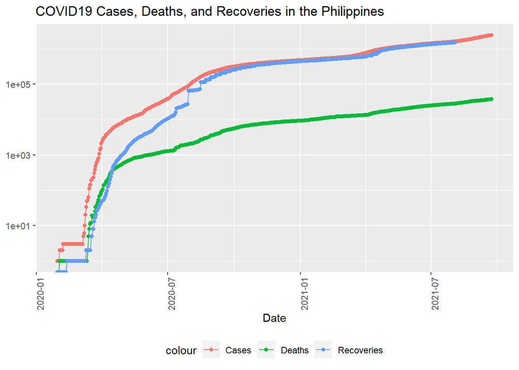

```r
ph_data %>%
  ggplot(aes(x=date, y=cases)) +
  geom_line(aes(color="Cases")) +
  geom_point(aes(color="Cases")) +

  geom_line(aes(y=deaths, color="Deaths")) +
  geom_point(aes(y=deaths, color="Deaths")) +

  geom_line(aes(y=recoveries, color="Recoveries")) +
  geom_point(aes(y=recoveries, color="Recoveries")) +

  scale_y_log10() +
  theme(legend.position="bottom",
        axis.text.x=element_text(angle=90)) +
  labs(title="COVID19 Cases, Deaths, and Recoveries in the Philippines",
       x="Date",
       y=NULL)
```

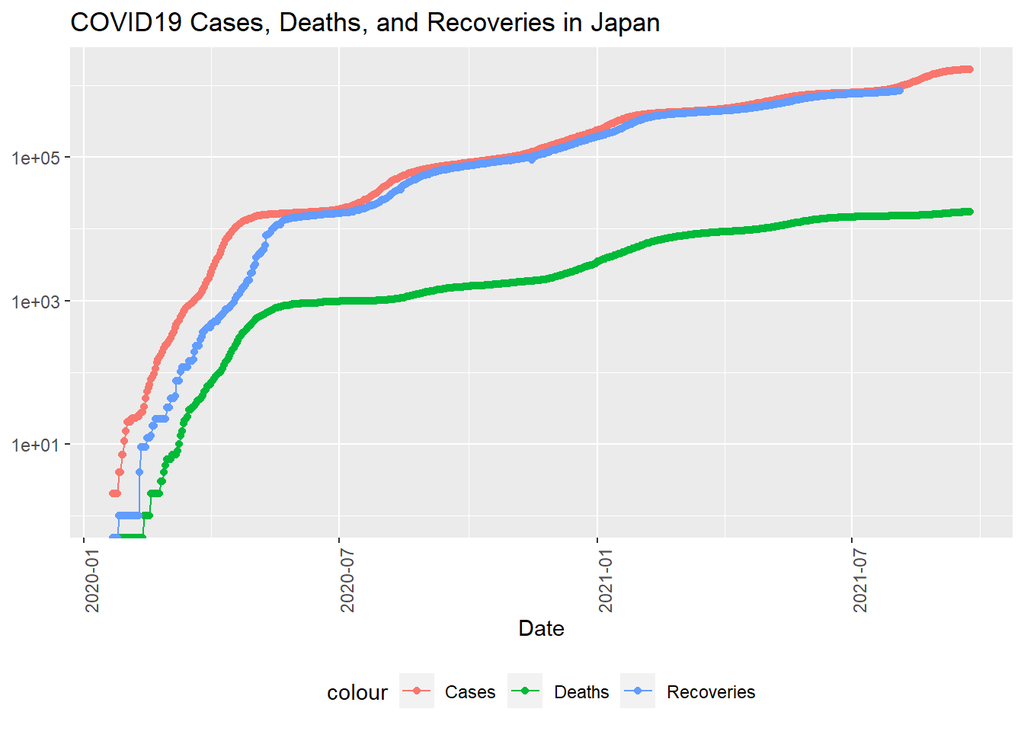

```r
jp_data %>%
  ggplot(aes(x=date, y=cases)) +
  geom_line(aes(color="Cases")) +
  geom_point(aes(color="Cases")) +

  geom_line(aes(y=deaths, color="Deaths")) +
  geom_point(aes(y=deaths, color="Deaths")) +

  geom_line(aes(y=recoveries, color="Recoveries")) +
  geom_point(aes(y=recoveries, color="Recoveries")) +

  scale_y_log10() +
  theme(legend.position="bottom",
        axis.text.x=element_text(angle=90)) +
  labs(title="COVID19 Cases, Deaths, and Recoveries in Japan",
       x="Date",
       y=NULL)
```

The graphs for both countries appear similar, although there seemed to be a time where the cases and deaths for the Philippines stagnated in early 2020. Let’s see how the two countries measure up when I include their cases in the same graph and do the same for their deaths and their recoveries.

It appears that in both countries, the number of recoveries closely follows the number of cases. This is quite good news.

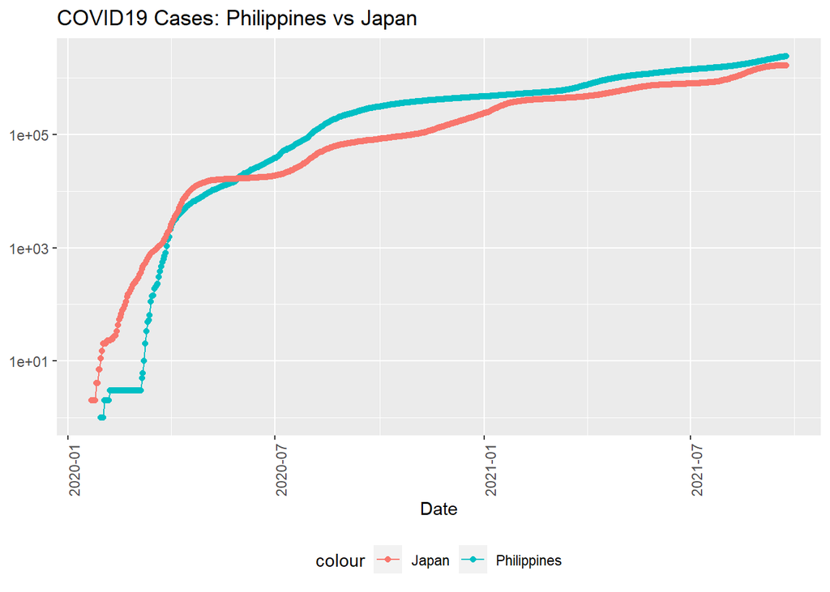

```r
ph_data %>%
  ggplot(aes(x=date, y=cases)) +
  geom_line(aes(color="Philippines")) +
  geom_point(aes(color="Philippines")) +

  geom_line(data=jp_data, aes(color="Japan")) +
  geom_point(data=jp_data, aes(color="Japan")) +

  scale_y_log10() +
  theme(legend.position="bottom",
        axis.text.x=element_text(angle=90)) +
  labs(title="COVID19 Cases: Philippines vs Japan",
       x="Date",
       y=NULL)
```

For this graph, we can see that the Philippines had a lower case count at the start, but it soon overtook Japan. There might have been something to do with the early stagnation of cases. Why was there a stagnation here?

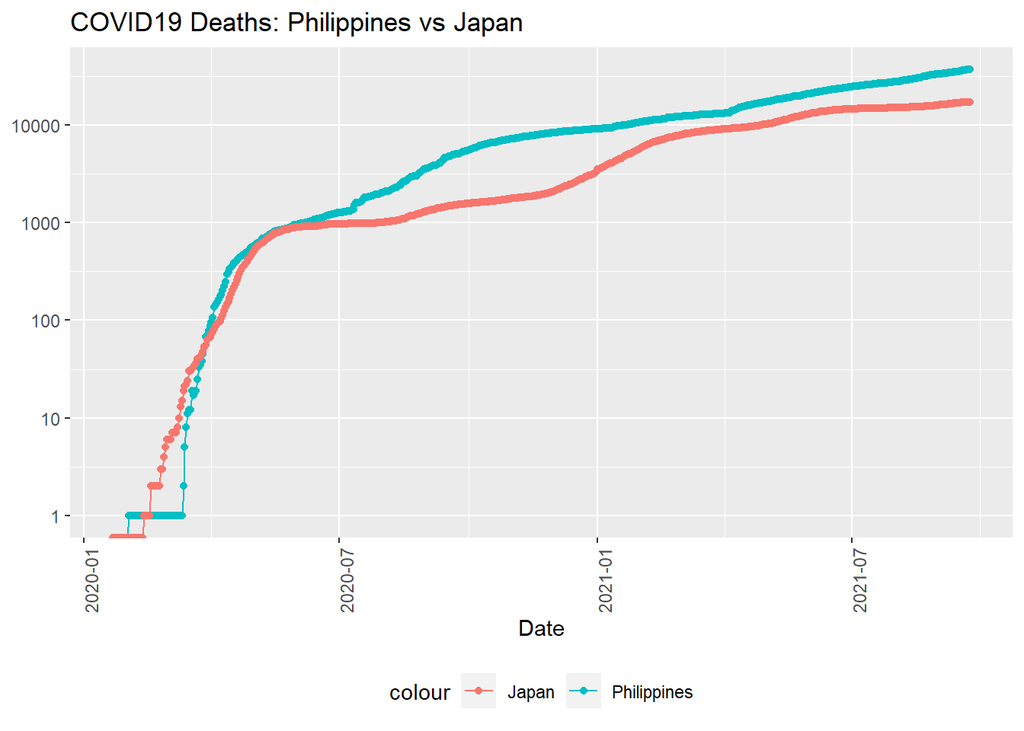

```r
ph_data %>%
  ggplot(aes(x=date, y=deaths)) +
  geom_line(aes(color="Philippines")) +
  geom_point(aes(color="Philippines")) +

  geom_line(data=jp_data, aes(color="Japan")) +
  geom_point(data=jp_data, aes(color="Japan")) +

  scale_y_log10() +
  theme(legend.position="bottom",
        axis.text.x=element_text(angle=90)) +
  labs(title="COVID19 Deaths: Philippines vs Japan",
       x="Date",
       y=NULL)
```

The same trend could be seen in this graph for deaths. However, the Philippines overtook Japan in the number of deaths much earlier in 2020.

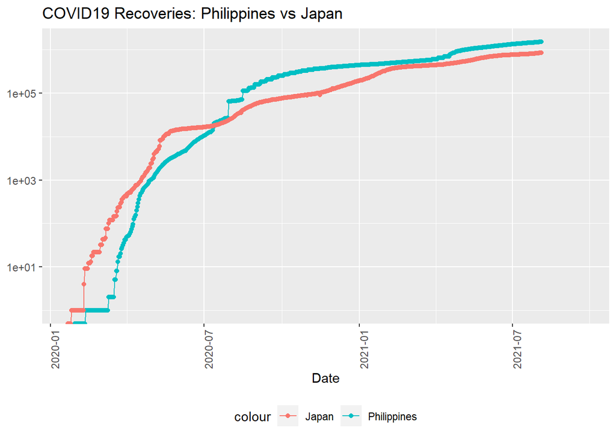

```r
ph_data %>%
  ggplot(aes(x=date, y=recoveries)) +
  geom_line(aes(color="Philippines")) +
  geom_point(aes(color="Philippines")) +

  geom_line(data=jp_data, aes(color="Japan")) +
  geom_point(data=jp_data, aes(color="Japan")) +

  scale_y_log10() +
  theme(legend.position="bottom",
        axis.text.x=element_text(angle=90)) +
  labs(title="COVID19 Recoveries: Philippines vs Japan",
       x="Date",
       y=NULL)
```

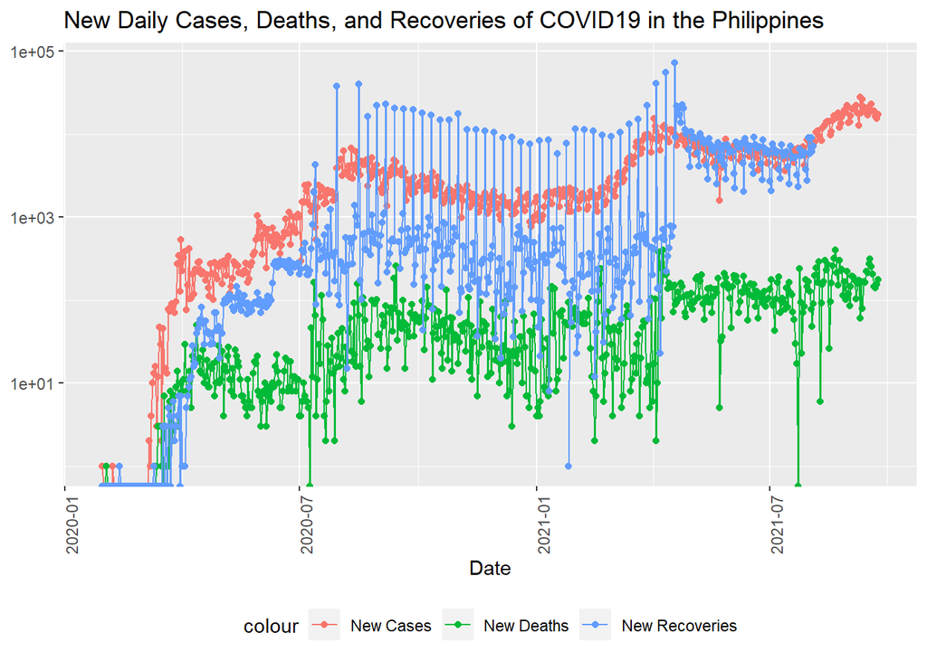

```r
# add columns for new cases, new deaths, and new recoveries
ph_data <- ph_data %>%
  mutate(new_cases=cases - lag(cases),
         new_deaths=deaths - lag(deaths),
         new_recoveries=recoveries - lag(recoveries))

ph_data$new_cases <- ifelse(is.na(ph_data$new_cases),
                            ph_data$cases,
                            ph_data$new_cases)

ph_data$new_deaths <- ifelse(is.na(ph_data$new_deaths),
                             ph_data$deaths,
                             ph_data$new_deaths)

ph_data$new_recoveries <- ifelse(is.na(ph_data$new_recoveries),
                                 ph_data$recoveries,
                                 ph_data$new_recoveries)

ph_data %>%
  ggplot(aes(x=date, y=new_cases)) +
  geom_line(aes(color="New Cases")) +
  geom_point(aes(color="New Cases")) +

  geom_line(aes(y=new_deaths, color="New Deaths")) +
  geom_point(aes(y=new_deaths, color="New Deaths")) +

  geom_line(aes(y=new_recoveries, color="New Recoveries")) +
  geom_point(aes(y=new_recoveries, color="New Recoveries")) +
  scale_y_log10() +
  theme(legend.position="bottom",
        axis.text.x=element_text(angle=90)) +
  labs(title="New Daily Cases, Deaths, and Recoveries of COVID19 in the Philippines",
       x="Date",
       y=NULL)
```

I thought of adding columns for new cases, new deaths, and new recoveries. I then wanted to see how these looked like over time.

There appears to be an upward trend, for all three new columns, but the number of new deaths and the number of new recoveries per day appear to vary wildly. Still, I can see an upward trend.

The number of new cases per day appears to be more stable compared to the number of new deaths and the number of new recoveries.

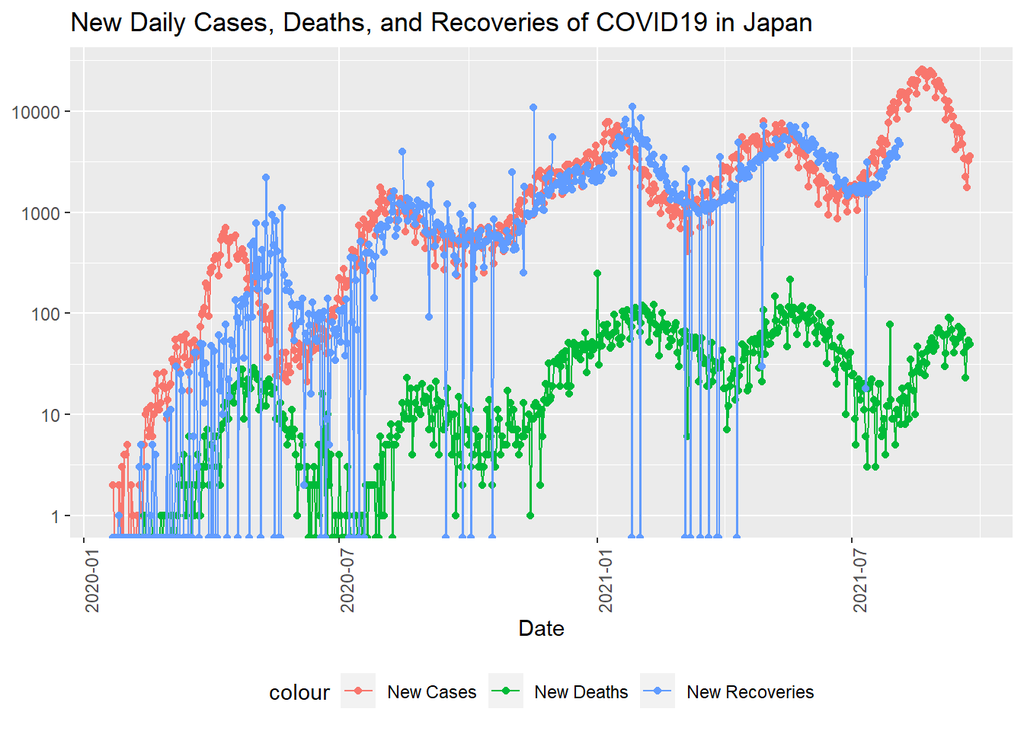

```r
# add columns for new cases, new deaths, and new recoveries
jp_data <- jp_data %>%
  mutate(new_cases=cases - lag(cases),
         new_deaths=deaths - lag(deaths),
         new_recoveries=recoveries - lag(recoveries))

jp_data$new_cases <- ifelse(is.na(jp_data$new_cases),
                            jp_data$cases,
                            jp_data$new_cases)

jp_data$new_deaths <- ifelse(is.na(jp_data$new_deaths),
                             jp_data$deaths,
                             jp_data$new_deaths)

jp_data$new_recoveries <- ifelse(is.na(jp_data$new_recoveries),
                                 jp_data$recoveries,
                                 jp_data$new_recoveries)

jp_data %>%
  ggplot(aes(x=date, y=new_cases)) +
  geom_line(aes(color="New Cases")) +
  geom_point(aes(color="New Cases")) +

  geom_line(aes(y=new_deaths, color="New Deaths")) +
  geom_point(aes(y=new_deaths, color="New Deaths")) +

  geom_line(aes(y=new_recoveries, color="New Recoveries")) +
  geom_point(aes(y=new_recoveries, color="New Recoveries")) +
  scale_y_log10() +
  theme(legend.position="bottom",
        axis.text.x=element_text(angle=90)) +
  labs(title="New Daily Cases, Deaths, and Recoveries of COVID19 in Japan",
       x="Date",
       y=NULL)
```

Japan’s case appears to be much different. The number of new cases also appears to be on an upward trend, with several surges. The number of new recoveries appears to follow the number of new cases closely, although there are times when that number dips to zero.

I would like to compare how the two countries measure up with the new columns.

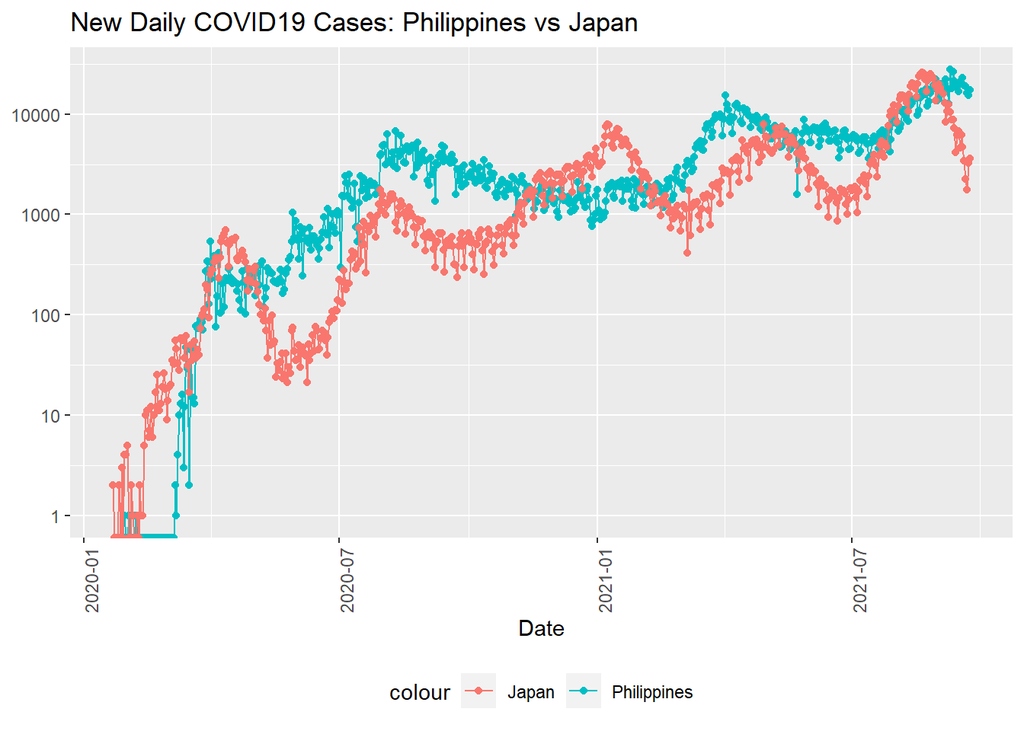

```r
ph_data %>%
  ggplot(aes(x=date, y=new_cases)) +
  geom_line(aes(color="Philippines")) +
  geom_point(aes(color="Philippines")) +

  geom_line(data=jp_data, aes(color="Japan")) +
  geom_point(data=jp_data, aes(color="Japan")) +

  scale_y_log10() +
  theme(legend.position="bottom",
        axis.text.x=element_text(angle=90)) +
  labs(title="New Daily COVID19 Cases: Philippines vs Japan",
       x="Date",
       y=NULL)
```

In general, Japan tends to have fewer new daily cases than the Philippines. The Philippines might have fewer cases from time to time, but these periods are shorter compared to when Japan had more new daily cases.

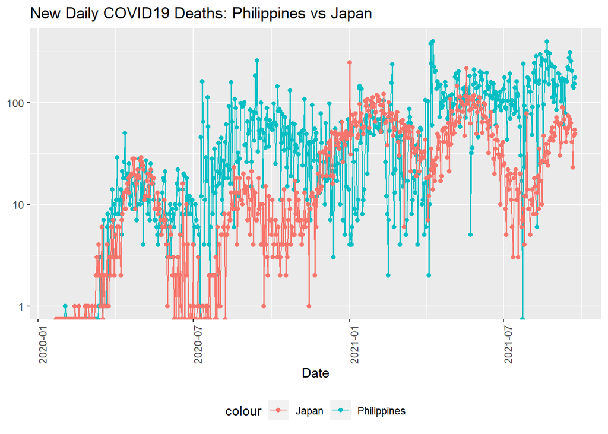

```r
ph_data %>%
  ggplot(aes(x=date, y=new_deaths)) +
  geom_line(aes(color="Philippines")) +
  geom_point(aes(color="Philippines")) +

  geom_line(data=jp_data, aes(color="Japan")) +
  geom_point(data=jp_data, aes(color="Japan")) +

  scale_y_log10() +
  theme(legend.position="bottom",
        axis.text.x=element_text(angle=90)) +
  labs(title="New Daily COVID19 Deaths: Philippines vs Japan",
       x="Date",
       y=NULL)
```

This graph doesn’t look very easy on the eyes. Still, Japan tends to have fewer new deaths compared to the Philippines.

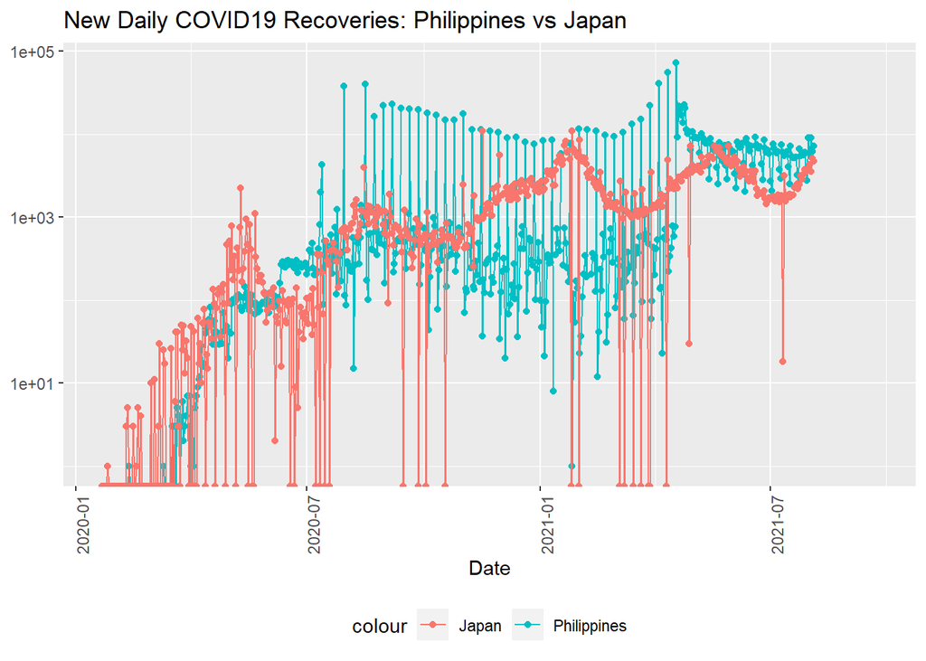

```r
ph_data %>%
  ggplot(aes(x=date, y=new_recoveries)) +
  geom_line(aes(color="Philippines")) +
  geom_point(aes(color="Philippines")) +

  geom_line(data=jp_data, aes(color="Japan")) +
  geom_point(data=jp_data, aes(color="Japan")) +

  scale_y_log10() +
  theme(legend.position="bottom",
        axis.text.x=element_text(angle=90)) +
  labs(title="New Daily COVID19 Recoveries: Philippines vs Japan",
       x="Date",
       y=NULL)
```

The number of new recoveries for both countries appear to be tied. There is a period where the number of new recoveries vary wildly, with Japan tending to have days where there were no new recoveries while the Philippines tended to have days where the number of new recoveries shot up before coming back down.

```r
ph_data <- ph_data %>%
  mutate(deaths_to_cases=deaths / cases)

jp_data <- jp_data %>%
  mutate(deaths_to_cases=deaths / cases)
```

I think another measure I should look into is the case fatality rate, or the number of deaths divided by the number of cases.

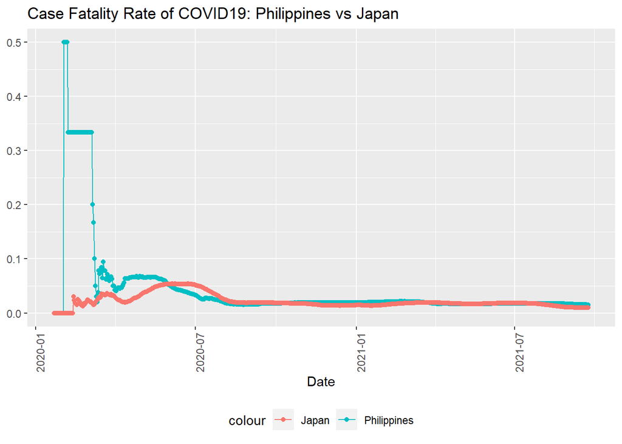

```r
ph_data %>%
  ggplot(aes(x=date, y=deaths_to_cases)) +
  geom_line(aes(color="Philippines")) +
  geom_point(aes(color="Philippines")) +

  geom_line(data=jp_data, aes(color="Japan")) +
  geom_point(data=jp_data, aes(color="Japan")) +

  theme(legend.position="bottom",
        axis.text.x=element_text(angle=90)) +
  labs(title="Case Fatality Rate of COVID19: Philippines vs Japan",
       x="Date",
       y=NULL)
```

It didn’t look so good for the Philippines at first, but the numbers went back down. The case fatality rate for both countries appears to have settled to almost close to 0. Let’s take a closer look at things in 2021.

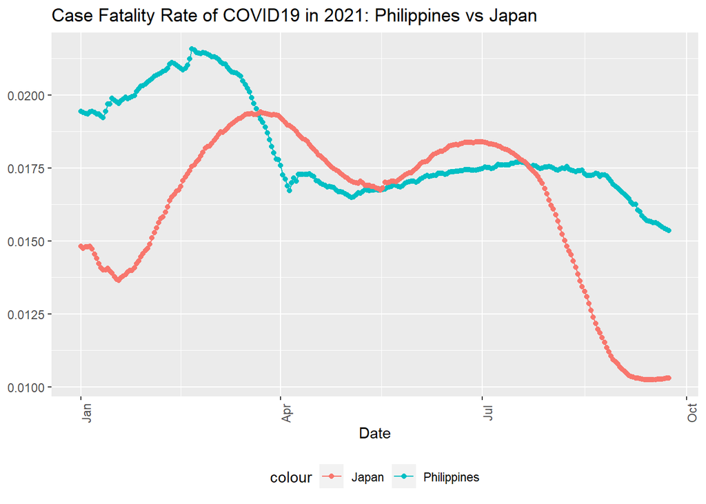

```r
# get data from 2021
ph_data_2021 <- ph_data %>%
  filter(date >= as.Date("2021-01-01"))

jp_data_2021 <- jp_data %>%
  filter(date >= as.Date("2021-01-01"))

ph_data_2021 %>%
  ggplot(aes(x=date, y=deaths_to_cases)) +
  geom_line(aes(color="Philippines")) +
  geom_point(aes(color="Philippines")) +

  geom_line(data=jp_data_2021, aes(color="Japan")) +
  geom_point(data=jp_data_2021, aes(color="Japan")) +

  theme(legend.position="bottom",
        axis.text.x=element_text(angle=90)) +
  labs(title="Case Fatality Rate of COVID19 in 2021: Philippines vs Japan",
       x="Date",
       y=NULL)
```

According to this graph, the case fatality rates went way down, below 0.02.

The lower bound for the Philippines appears to be 0.015 while it is 0.010 for Japan.

This is great since this means that COVID is not particularly fatal. It appears that for every 100 cases, I can expect around 1 or 2 deaths in the Philippines while I can expect close to 1 death in Japan.

I would like to create a model to see how things would play out in the future. I think it’s more accurate to use only this year’s data with regards to case fatality rate since the outbreak was such a sudden shock to the world last year. I think now that the world has had a chance to stabilize somewhat, this year’s numbers should be more relevant.

```r
mod_ph <- lm(deaths_to_cases ~ date, data=ph_data_2021)
summary(mod_ph)
```

```
##
## Call:
## lm(formula = deaths_to_cases ~ date, data = ph_data_2021)
##
## Residuals:
##        Min         1Q     Median         3Q        Max
## -0.0020431 -0.0008680  0.0000375  0.0007485  0.0020736
##
## Coefficients:
##               Estimate Std. Error t value Pr(>|t|)
## (Intercept)  3.328e-01  1.585e-02   21.00   <2e-16 ***
## date        -1.677e-05  8.446e-07  -19.86   <2e-16 ***
## ---
## Signif. codes:  0 '***' 0.001 '**' 0.01 '*' 0.05 '.' 0.1 ' ' 1
##
## Residual standard error: 0.001058 on 264 degrees of freedom
## Multiple R-squared:  0.599,  Adjusted R-squared:  0.5975
## F-statistic: 394.4 on 1 and 264 DF,  p-value: < 2.2e-16
```

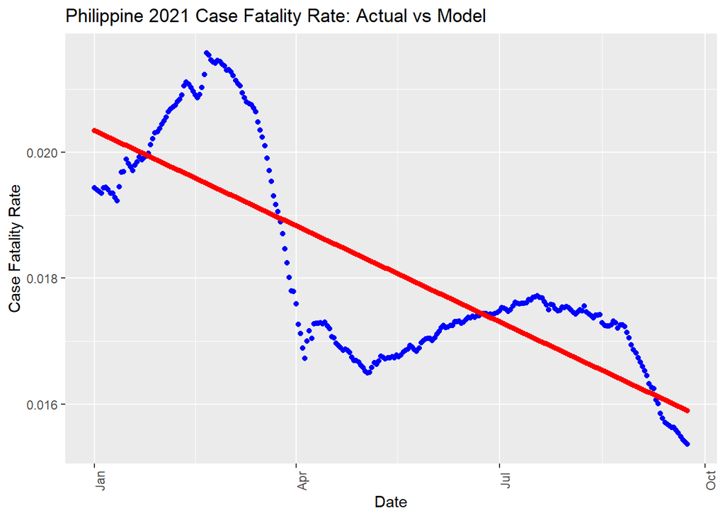

```r
ph_w_pred <- ph_data_2021 %>% mutate(pred = predict(mod_ph))

ph_w_pred %>% ggplot() +
  geom_point(aes(x=date, y=deaths_to_cases), color="blue") +
  geom_point(aes(x=date, y=pred), color="red") +
  theme(legend.position="bottom",
        axis.text.x = element_text(angle=90)) +
  labs(title="Philippine 2021 Case Fatality Rate: Actual vs Model",
       y="Case Fatality Rate",
       x="Date")
```

```r
mod_jp <- lm(deaths_to_cases ~ date, data=jp_data_2021)
summary(mod_jp)
```

```
##
## Call:
## lm(formula = deaths_to_cases ~ date, data = jp_data_2021)
##
## Residuals:
##        Min         1Q     Median         3Q        Max
## -0.0043418 -0.0025246  0.0009081  0.0021334  0.0028167
##
## Coefficients:
##               Estimate Std. Error t value Pr(>|t|)
## (Intercept)  2.735e-01  3.717e-02   7.358 2.37e-12 ***
## date        -1.371e-05  1.982e-06  -6.921 3.40e-11 ***
## ---
## Signif. codes:  0 '***' 0.001 '**' 0.01 '*' 0.05 '.' 0.1 ' ' 1
##
## Residual standard error: 0.002482 on 264 degrees of freedom
## Multiple R-squared:  0.1536, Adjusted R-squared:  0.1504
## F-statistic:  47.9 on 1 and 264 DF,  p-value: 3.396e-11
```

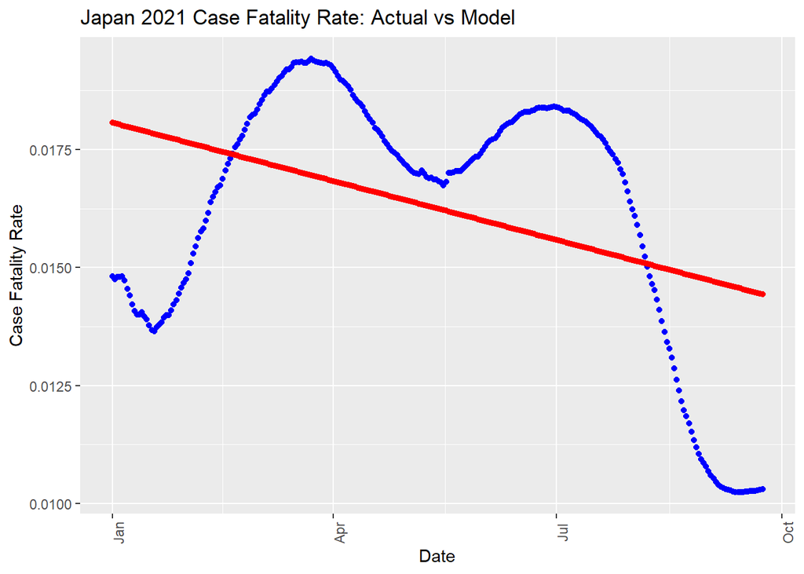

```r
jp_w_pred <- jp_data_2021 %>% mutate(pred = predict(mod_jp))

jp_w_pred %>% ggplot() +
  geom_point(aes(x=date, y=deaths_to_cases), color="blue") +
  geom_point(aes(x=date, y=pred), color="red") +
  theme(legend.position="bottom",
        axis.text.x = element_text(angle=90)) +
  labs(title="Japan 2021 Case Fatality Rate: Actual vs Model",
       y="Case Fatality Rate",
       x="Date")
```

Both models predict a downward trend for both countries. This is great news, especially after taking into consideration that my model predicts that the ratio of deaths to cases is higher than was observed in September 2021.

# Conclusion

It appears that there is a downward trend in the case fatality rates for both countries. The rates for both countries appear to continue going down, as predicted by my models.

It appears that Japan has a slightly lower case fatality rate as of September 2021. Perhaps it was a good thing for me to have come here, after all. I do miss seeing my family, however.

I could only look forward to the day that the numbers say zero. However, this may be impossible, and I have to temper my expectations so.

I have heard that age is a comorbidity when it came to COVID. Given that Japan’s population is aging, I would have expected that Japan’s case fatality rate would have been higher. However, I should also take into consideration that Japan’s healthcare system could be superior compared to the Philippines’s.

Focusing solely on raw cases, deaths, and recoveries might not paint an accurate picture, so I opted to go for a metric like the case fatality rate. This would control for the different numbers of cases and deaths.